# Drinking Trends around the World

Antonio Giannaccari

2020-10-20

# 1 Where Do People Drink The Most Beer, Wine And Spirits?

```r
library(fivethirtyeight)
data(drinks)
```

## 1.1 Data types and missing values

```r
str(drinks)
```

```
## tibble [193 × 5] (S3: tbl_df/tbl/data.frame)
##  $ country                     : chr [1:193] "Afghanistan" "Albania" "Algeria" "Andorra" ...
##  $ beer_servings               : int [1:193] 0 89 25 245 217 102 193 21 261 279 ...
##  $ spirit_servings             : int [1:193] 0 132 0 138 57 128 25 179 72 75 ...
##  $ wine_servings               : int [1:193] 0 54 14 312 45 45 221 11 212 191 ...
##  $ total_litres_of_pure_alcohol: num [1:193] 0 4.9 0.7 12.4 5.9 4.9 8.3 3.8 10.4 9.7 ...
##  - attr(*, "spec")=
##   .. cols(
##   ..   country = col_character(),
##   ..   beer_servings = col_integer(),
##   ..   spirit_servings = col_integer(),
##   ..   wine_servings = col_integer(),
##   ..   total_litres_of_pure_alcohol = col_double()
##   .. )
```

```r
apply(drinks[,c(2:5)],2,function(x) length(which(x == 0)))
```

```
##                beer_servings              spirit_servings
##                           15                           23
##                wine_servings total_litres_of_pure_alcohol
##                           31                           13
```

When dealing with datasets, it is important to make sure we have a good idea of what the data looks like. As we can see above, the variable types are “character” for one column and “numeric” for the remaining four, with one column with decimal points. For what concerns missing information, you can see that for some countries such as North Korea no information was recorded regardless of the alcohol type. In other cases, such as Burundi, the information was only partially filled, meaning some types of liquor were recorded. Either way, the missing information would provide sligthly misleading information given the outliers.

## 1.2 Beer Consumption

```r
top25beer <- arrange(drinks, desc(drinks$beer_servings)) %>%
  slice(1:25)


print(top25beer)
```

```
## # A tibble: 25 x 5
##    country     beer_servings spirit_servings wine_servings total_litres_of_pure…
##    <chr>               <int>           <int>         <int>                 <dbl>
##  1 Namibia               376               3             1                   6.8
##  2 Czech Repu…           361             170           134                  11.8
##  3 Gabon                 347              98            59                   8.9
##  4 Germany               346             117           175                  11.3
##  5 Lithuania             343             244            56                  12.9
##  6 Poland                343             215            56                  10.9
##  7 Venezuela             333             100             3                   7.7
##  8 Ireland               313             118           165                  11.4
##  9 Palau                 306              63            23                   6.9
## 10 Romania               297             122           167                  10.4
## # … with 15 more rows
```

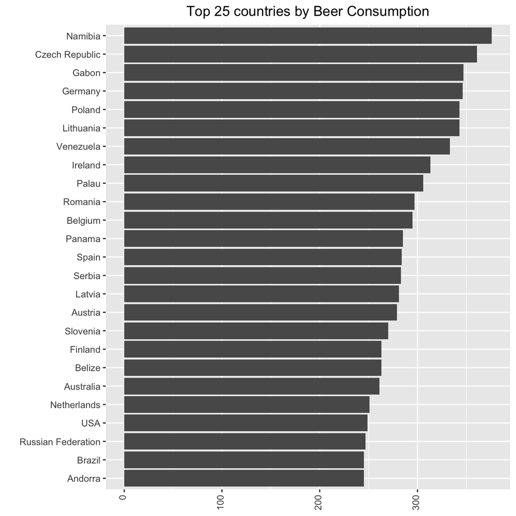

```r
ggplot(data = top25beer) + aes(x= reorder(country, beer_servings),y=beer_servings) +
  geom_col() +
  ggtitle("Top 25 countries by Beer Consumption") +
  xlab("") +
  ylab("Beer  Servings")+
  theme(plot.title = element_text(hjust = 0.5),
        axis.text.x = element_text(angle = 90, vjust = 0.25, hjust=1),
        axis.title.x = element_blank(),
        )+
  coord_flip()+
  NULL
```

## 1.3 Wine Consumption

```r
top25wine <- arrange(drinks, desc(drinks$wine_servings)) %>%
  slice(1:25)


print(top25wine)
```

```
## # A tibble: 25 x 5
##    country      beer_servings spirit_servings wine_servings total_litres_of_pur…
##    <chr>                <int>           <int>         <int>                <dbl>
##  1 France                 127             151           370                 11.8
##  2 Portugal               194              67           339                 11
##  3 Andorra                245             138           312                 12.4
##  4 Switzerland            185             100           280                 10.2
##  5 Denmark                224              81           278                 10.4
##  6 Slovenia               270              51           276                 10.6
##  7 Luxembourg             236             133           271                 11.4
##  8 Croatia                230              87           254                 10.2
##  9 Italy                   85              42           237                  6.5
## 10 Equatorial …            92               0           233                  5.8
## # … with 15 more rows
```

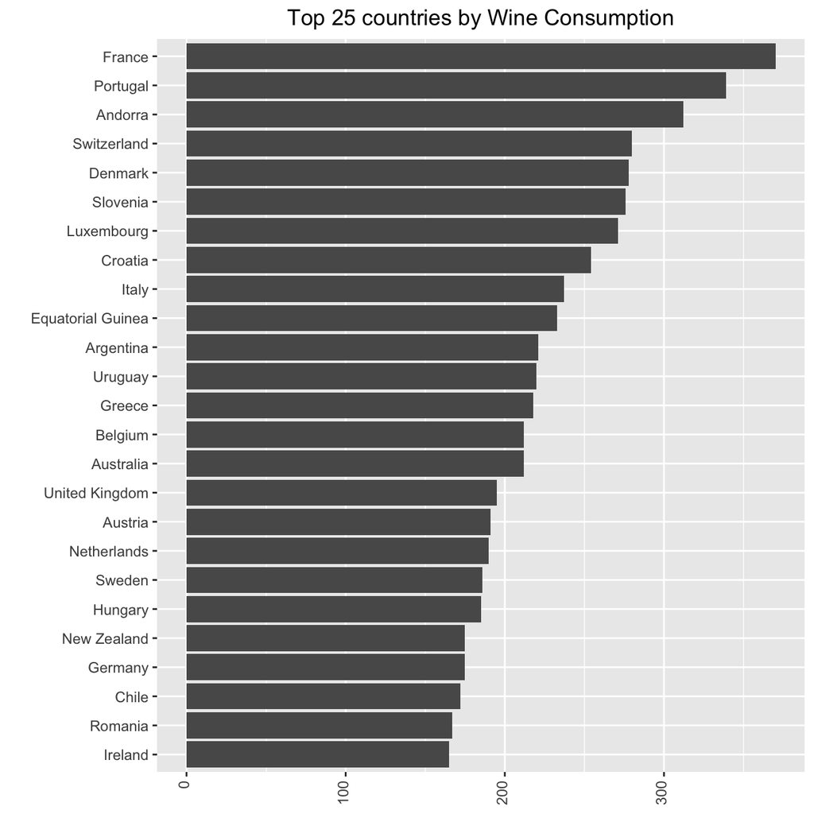

```r
ggplot(data = top25wine) + aes(x= reorder(country, wine_servings),y=wine_servings) +
   ggtitle("Top 25 countries by Wine Consumption") +
  geom_col() +
  xlab("") +
  ylab("Wine  Servings")+
  theme(plot.title = element_text(hjust = 0.5),
        axis.text.x = element_text(angle = 90, vjust = 0.25, hjust=1),
        axis.title.x = element_blank(),
        )+
   coord_flip()+
  NULL
```

## 1.4 Spirit Consumption

```r
top25spirit <- arrange(drinks, desc(drinks$spirit_servings)) %>%
  slice(1:25)


print(top25spirit)
```

```
## # A tibble: 25 x 5
##    country      beer_servings spirit_servings wine_servings total_litres_of_pur…
##    <chr>                <int>           <int>         <int>                <dbl>
##  1 Grenada                199             438            28                 11.9
##  2 Belarus                142             373            42                 14.4
##  3 Haiti                    1             326             1                  5.9
##  4 Russian Fed…           247             326            73                 11.5
##  5 St. Lucia              171             315            71                 10.1
##  6 Guyana                  93             302             1                  7.1
##  7 Slovakia               196             293           116                 11.4
##  8 Dominica                52             286            26                  6.6
##  9 Thailand                99             258             1                  6.4
## 10 Cook Islands             0             254            74                  5.9
## # … with 15 more rows
```

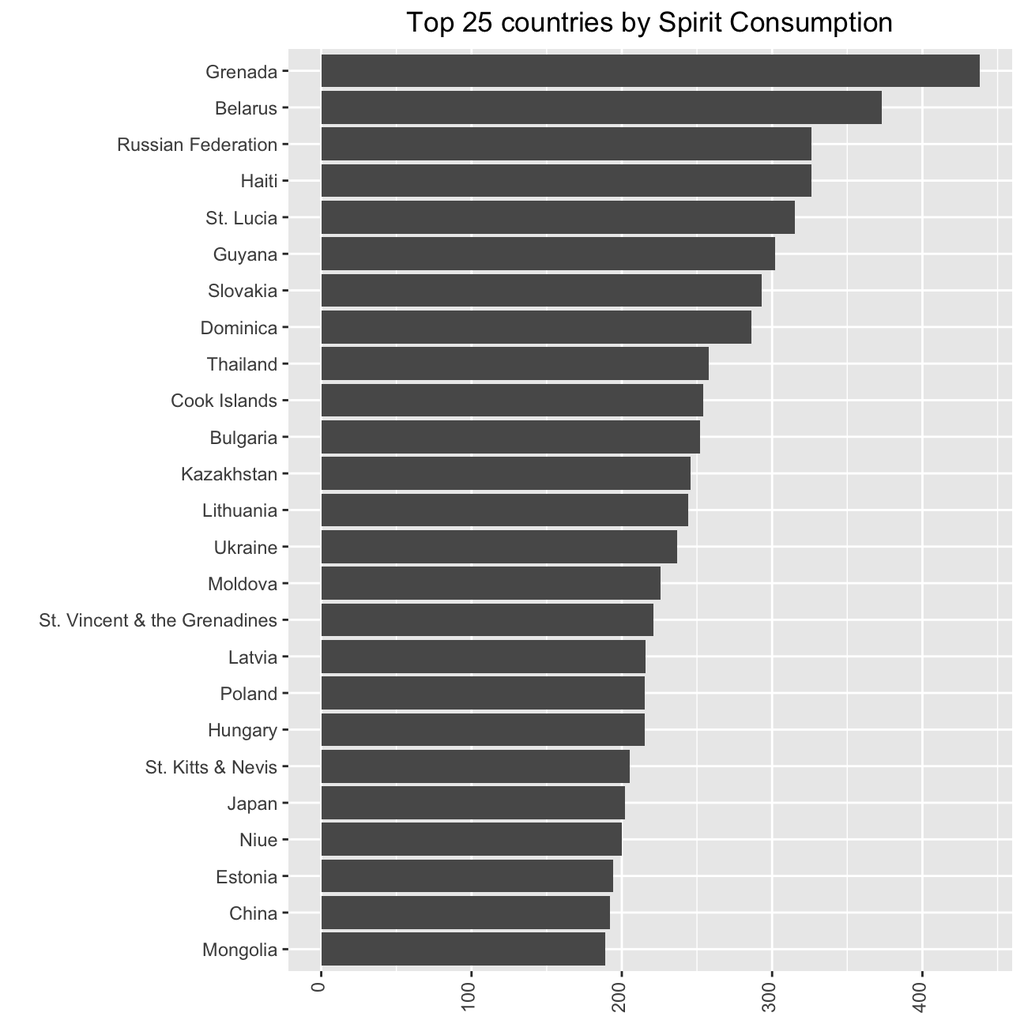

```r
ggplot(data = top25spirit) + aes(x= reorder(country, spirit_servings),y=spirit_servings) +
 ggtitle("Top 25 countries by Spirit Consumption") +
  geom_col() +
  xlab("") +
  ylab("Spirit  Servings")+
  theme(plot.title = element_text(hjust = 0.5),
        axis.text.x = element_text(angle = 90, vjust = 0.25, hjust=1),
        axis.title.x = element_blank(),
        )+
   coord_flip()+
  NULL
```

The alcohol consumption analysis provides both some expected and some unexpected insights on the drinking trends of countries around the globe. For what concerns beer, I was not too surprised to see Namibia be the highest consumer: several African countries have displayed excess-drinking trends when it comes to beer, and with Namibia being a former German colony with strong connections to Germany still to date, there probably are large imports of beer. Other than Germany, it is not surprising to see Czech Republic, Ireland, and Poland in the top 10.

For what concerns wine, we can notice that many countries that appear on the top 25 are European. I think this is not only the case because wine is a specialty of the region, but also because wine is a more expensive drink compared to beer, therefore it is expected to be consumed in relatively richer countries. Finally, the liquor drinking trends were the ones that displayed more variety, both when it comes to geographic location and economic situation. We see countries in the Caribbean, in Eastern Europe, and Southeast Asia among the largest consumers. This shows that unlike beer and wine, spirits tend to be consumed by a more diverse group of individuals.